# Estimación del Valor Económico de la Reducción de la Contaminación en una playa en Massachussets, Estados Unidos

Jorge Martelo

20/5/2021

La base de datos de este ejercicio fue tomada de un estudio que pretende mediante la aplicación del método del costo de viaje estimar los beneficios en recreación debido a reducciones de PCB´s (Policloruros Bencenos) del agua en un puerto de Massachusetts en Estados Unidos. El estudio fue realizado mediante entrevistas telefónicas. Se seleccionó una muestra aleatoria de familias que representativa de la población en estudio. Específicamente, el análisis conllevó a la estimación del efecto que tiene la reducción de dicho contaminante sobre la demanda por viajes a la playa. El propósito del estudio es valorar el acceso a la playa.

El conjunto de datos incluye las siguientes variables:

- x1: Variable dependiente que representa el número de viajes realizados a la playa por temporada.
- x2: Variable independiente que representa la distancia a la playa en millas.
- x3: Variable independiente que representa el tiempo de viaje a la playa en horas.
- x4: Variable independiente que representa el precio completo a la playa (distancia ida y vuelta en millas multiplicado por el valor por milla (US 0.2 /milla) más el tiempo de ida y vuelta multiplicado por el valor del tiempo).
- x5: Variable independiente que representa el número de viajes realizados a lugares alternativos de menor costo.
- x6: Variable independiente que representa la distancia en millas a lugares alternativos de menor costo.
- x7: Variable independiente que representa el tiempo a lugares alternativos de menor costo.
- x8: Variable independiente que representa el precio completo a lugares alternativos (sustitutos) de menor costo.
- x9: Variable independiente que representa el valor asignado al tiempo (US/ minuto).
- x10: Variable independiente que representa la edad en años del jefe de familia.
- x11: Variable independiente que representa el número de adultos por familia.
- x12: Variable independiente que representa el número de niños por familia.
- x13: Variable binaria que toma el valor de 1 si la familia tiene permisos de temporada a la playa.
- x14: Variable binaria que toma el valor de 1 si la familia tiene pases de temporada para cualquier otra playa.

Se cuenta con 527 observaciones disponibles, las cuales se encuentran en el archivo FORTFINX.ASC. Resuelva:

### a) Carga de datos a R y preprocesamiento

1. Cargue los datos a R y utilice la funcion head para explorar las primeras filas

```r
library(readxl)
CV <- read_excel("C:/Users/marteloa.5/Google Drive/Teleperformance/Sesiones de R/Costo de viaje/COSTOS_VIAJE_Fortfinx (1).xls")
head(CV)
```

```
## # A tibble: 6 x 14
##      X1    X2    X3    X4    X5    X6    X7    X8     X9   X10   X11   X12
##   <dbl> <dbl> <dbl> <dbl> <dbl> <dbl> <dbl> <dbl>  <dbl> <dbl> <dbl> <dbl>
## 1     0  2.48  10    2.33    20  6.05 15     4.42 0.0668    35     3     1
## 2     0  3.47  11.7  3.35     0  0.9   4.75  1.16 0.0837    35     2     1
## 3     0  2.8   15    4.86     1  3.39 15     5.09 0.124     21     2     1
## 4     0  6.87  25    7.22     0  9.24 20.9   7.43 0.0895    35     2     2
## 5     0  8.71  15    4.40     0  2.7  15     2.00 0.0305    55     2     0
## 6     0  3.83  15    4.35    12  0.54  5     1.16 0.094     35     2     1
## # ... with 2 more variables: X13 <dbl>, X14 <dbl>
```

2. Analizar la estructura interna de los datos, en caso de que una variable no tenga el formato deseado, asignarlo.

```r
str(CV)
```

```
## tibble [527 x 14] (S3: tbl_df/tbl/data.frame)
##  $ X1 : num [1:527] 0 0 0 0 0 0 0 0 0 0 ...
##  $ X2 : num [1:527] 2.48 3.47 2.8 6.87 8.71 3.83 3.19 4.24 2.93 3.66 ...
##  $ X3 : num [1:527] 10 11.7 15 25 15 15 15 21.4 11.3 10 ...
##  $ X4 : num [1:527] 2.33 3.35 4.86 7.22 4.4 ...
##  $ X5 : num [1:527] 20 0 1 0 0 12 4 0 1 0 ...
##  $ X6 : num [1:527] 6.05 0.9 3.39 9.24 2.7 0.54 2.48 5.17 3.85 3.85 ...
##  $ X7 : num [1:527] 15 4.75 15 20.86 15 ...
##  $ X8 : num [1:527] 4.42 1.16 5.09 7.43 2 ...
##  $ X9 : num [1:527] 0.0668 0.0837 0.1245 0.0895 0.0305 ...
##  $ X10: num [1:527] 35 35 21 35 55 35 55 70 55 35 ...
##  $ X11: num [1:527] 3 2 2 2 2 2 4 1 2 2 ...
##  $ X12: num [1:527] 1 1 1 2 0 1 0 0 0 2 ...
##  $ X13: num [1:527] 0 0 0 0 0 0 0 0 0 0 ...
##  $ X14: num [1:527] 1 0 0 0 1 0 0 0 0 1 ...
```

```r
CV$X1 <- as.integer(CV$X1)
CV$X13 <- as.factor(CV$X13)
CV$X14 <- as.factor(CV$X14)
```

#### b) Analisis descriptivo

3. Realice un resumen descriptivo de las variables. Comente los resultados sobre las variables **X10** y **X11**. Adicionalmente mencione si la data presenta truncamiento o censura.

```r
summary(CV)
```

```
##        X1               X2              X3             X4
##  Min.   : 0.000   Min.   :1.250   Min.   : 1.0   Min.   : 0.672
##  1st Qu.: 0.000   1st Qu.:3.130   1st Qu.:11.7   1st Qu.: 2.862
##  Median : 0.000   Median :3.680   Median :15.0   Median : 3.954
##  Mean   : 1.583   Mean   :4.455   Mean   :16.4   Mean   : 4.214
##  3rd Qu.: 1.000   3rd Qu.:6.190   3rd Qu.:20.0   3rd Qu.: 5.267
##  Max.   :37.000   Max.   :8.710   Max.   :60.0   Max.   :14.800
##        X5                X6              X7              X8
##  Min.   :  0.000   Min.   :0.510   Min.   : 1.00   Min.   :0.302
##  1st Qu.:  0.000   1st Qu.:2.700   1st Qu.: 8.00   1st Qu.:2.039
##  Median :  0.000   Median :3.370   Median :11.00   Median :3.127
##  Mean   :  8.842   Mean   :3.758   Mean   :11.85   Mean   :3.252
##  3rd Qu.:  4.000   3rd Qu.:5.125   3rd Qu.:15.00   3rd Qu.:4.284
##  Max.   :730.000   Max.   :9.240   Max.   :30.00   Max.   :9.360
##        X9               X10             X11             X12        X13
##  Min.   :0.03050   Min.   : 8.00   Min.   :0.000   Min.   :0.000   0:487
##  1st Qu.:0.04517   1st Qu.:35.00   1st Qu.:2.000   1st Qu.:0.000   1: 40
##  Median :0.07817   Median :35.00   Median :2.000   Median :0.000
##  Mean   :0.07444   Mean   :42.76   Mean   :2.302   Mean   :0.888
##  3rd Qu.:0.08891   3rd Qu.:55.00   3rd Qu.:3.000   3rd Qu.:2.000
##  Max.   :0.16030   Max.   :70.00   Max.   :8.000   Max.   :7.000
##  X14
##  0:421
##  1:106
##
##
##
##
```

4. Realice un gráfico de barras para la variable X1 y un grafico de cajas y bigotes para la variable X4. Que informacion puede inferir de ellos?

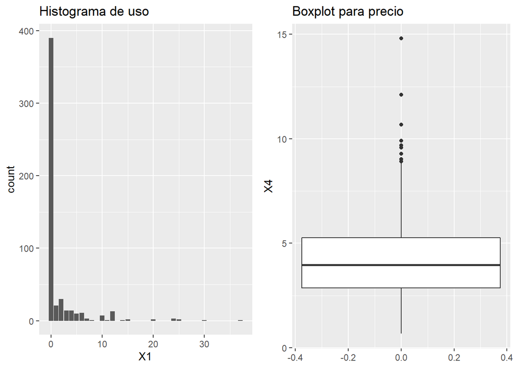

```r
library(ggplot2)
library(gridExtra)
grid.arrange(
  ggplot(CV)+
    aes(x = X1)+
    geom_bar()+
    ggtitle("Histograma de uso"),

  ggplot(CV)+
    aes(y = X4)+
    geom_boxplot()+
    ggtitle("Boxplot para precio"),

  ncol = 2)
```

### c) Seleccion de variables y especificacion del modelo

5. Evalue si existen variables redundantes en las variables endogenas y utilice un gráfico de dispersion para un par de variables altamente correlacionadas

```r
# Matriz de correlacion
cor(CV[, -c(1, 13, 14)])
```

```
##              X2          X3          X4           X5           X6
## X2   1.00000000  0.36297242  0.68718418 -0.017689121  0.245244318
## X3   0.36297242  1.00000000  0.71845761  0.019246177  0.173343683
## X4   0.68718418  0.71845761  1.00000000 -0.029232295  0.245446549
## X5  -0.01768912  0.01924618 -0.02923230  1.000000000 -0.148565014
## X6   0.24524432  0.17334368  0.24544655 -0.148565014  1.000000000
## X7  -0.11669762  0.29409640  0.10247315 -0.131606080  0.429596489
## X8   0.09595632  0.23779925  0.39716838 -0.157888268  0.775871989
## X9   0.08130732 -0.02272837  0.50177378 -0.043673388  0.070062779
## X10  0.02425376  0.08786435 -0.09398141 -0.058267891 -0.029993351
## X11  0.06102144 -0.02443569  0.04749426 -0.018990587  0.105837689
## X12  0.01178060 -0.03267632  0.03702553 -0.008102168  0.004777008
##               X7          X8          X9         X10          X11
## X2  -0.116697622  0.09595632  0.08130732  0.02425376  0.061021441
## X3   0.294096397  0.23779925 -0.02272837  0.08786435 -0.024435693
## X4   0.102473153  0.39716838  0.50177378 -0.09398141  0.047494257
## X5  -0.131606080 -0.15788827 -0.04367339 -0.05826789 -0.018990587
## X6   0.429596489  0.77587199  0.07006278 -0.02999335  0.105837689
## X7   1.000000000  0.73719786 -0.05598338  0.02134804 -0.002499566
## X8   0.737197860  1.00000000  0.40822431 -0.14590183  0.084612850
## X9  -0.055983377  0.40822431  1.00000000 -0.32384209  0.067470043
## X10  0.021348042 -0.14590183 -0.32384209  1.00000000 -0.211841658
## X11 -0.002499566  0.08461285  0.06747004 -0.21184166  1.000000000
## X12  0.003729072  0.05572977  0.10723975 -0.34691206  0.078863329
##              X12
## X2   0.011780604
## X3  -0.032676323
## X4   0.037025530
## X5  -0.008102168
## X6   0.004777008
## X7   0.003729072
## X8   0.055729766
## X9   0.107239747
## X10 -0.346912061
## X11  0.078863329
## X12  1.000000000
```

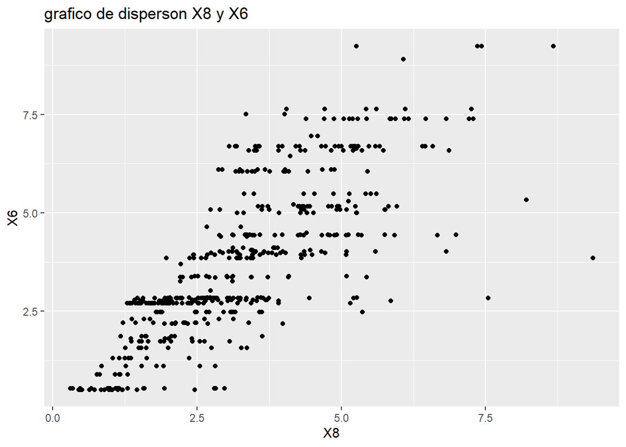

```r
# Gráfico de dispersion
ggplot(CV)+
  aes(x = X8, y = X6)+
  geom_point()+
  ggtitle("grafico de disperson X8 y X6")
```

```r
# Data sin variables redundates
CV2 <- CV[, -c(3, 6, 7)]
head(CV2)
```

```
## # A tibble: 6 x 11
##      X1    X2    X4    X5    X8     X9   X10   X11   X12 X13   X14
##   <int> <dbl> <dbl> <dbl> <dbl>  <dbl> <dbl> <dbl> <dbl> <fct> <fct>
## 1     0  2.48  2.33    20  4.42 0.0668    35     3     1 0     1
## 2     0  3.47  3.35     0  1.16 0.0837    35     2     1 0     0
## 3     0  2.8   4.86     1  5.09 0.124     21     2     1 0     0
## 4     0  6.87  7.22     0  7.43 0.0895    35     2     2 0     0
## 5     0  8.71  4.40     0  2.00 0.0305    55     2     0 0     1
## 6     0  3.83  4.35    12  1.16 0.094     35     2     1 0     0
```

Una vez depurada la data se debe especificar el tipo de modelo a estimar. El tipo de modelo depende principalemnte de las caracteristicas del problema que se esta analizando, como el tipo de variable dependiente. La tabla a continuacion muestra algunos de los modelos mas utilizados dentro del ambito econometrico:

| Modelo | Método | Tipo de variable respuesta |
| --- | --- | --- |
| Regresión lineal | Mínimos cuadrados ordinarios | Valores continuos es continua |
| LOGIT | Maximo verosimilitud | Valores de 0 y 1 |
| Poisson | Maximo verosimilitud | Valores enteros |
| Binomial Negativo | Maximo verosimilitud | Valores enteros |

#### d) Estimacion y validacion de modelo

6. Estime una regresion Poisson. Interprete los coeficientes, la significancia de las variables y evalue la prosibilidad de sobredispersión. En caso de que existan variables no significativas, retiralas, estimar e interpretar el mejor modelo.

```r
# Modelo Poisson (interprete)
PoissonM <- glm(data = CV2,
                X1 ~ .,
                family = poisson)
summary(PoissonM)
```

```
##
## Call:
## glm(formula = X1 ~ ., family = poisson, data = CV2)
##
## Deviance Residuals:
##     Min       1Q   Median       3Q      Max
## -3.6179  -1.8525  -1.2767  -0.6439  10.6919
##
## Coefficients:
##               Estimate Std. Error z value Pr(>|z|)
## (Intercept)  1.4098979  0.2192420   6.431 1.27e-10 ***
## X2          -0.0473888  0.0406861  -1.165 0.244123
## X4          -0.3877524  0.0475903  -8.148 3.71e-16 ***
## X5           0.0021093  0.0004672   4.515 6.33e-06 ***
## X8          -0.0285294  0.0283369  -1.007 0.314034
## X9           7.1345516  1.8691454   3.817 0.000135 ***
## X10         -0.0029151  0.0024043  -1.212 0.225335
## X11          0.1666960  0.0281162   5.929 3.05e-09 ***
## X12         -0.0795867  0.0313794  -2.536 0.011204 *
## X131         0.6606977  0.1172685   5.634 1.76e-08 ***
## X141        -0.4448485  0.1121961  -3.965 7.34e-05 ***
## ---
## Signif. codes:  0 '***' 0.001 '**' 0.01 '*' 0.05 '.' 0.1 ' ' 1
##
## (Dispersion parameter for poisson family taken to be 1)
##
##     Null deviance: 2954.8  on 526  degrees of freedom
## Residual deviance: 2547.4  on 516  degrees of freedom
## AIC: 3016.7
##
## Number of Fisher Scoring iterations: 7
```

```r
# Modelo Poisson version 2
PoissonM <- glm(data = CV2,
                X1 ~ X4 + X5 + X9 + X11 + X12 + X13 + X14,
                family = poisson)
summary(PoissonM)
```

```
##
## Call:
## glm(formula = X1 ~ X4 + X5 + X9 + X11 + X12 + X13 + X14, family = poisson,
##     data = CV2)
##
## Deviance Residuals:
##     Min       1Q   Median       3Q      Max
## -3.7233  -1.8336  -1.3014  -0.6272  10.5863
##
## Coefficients:
##               Estimate Std. Error z value Pr(>|z|)
## (Intercept)  1.0988933  0.1282150   8.571  < 2e-16 ***
## X4          -0.4379642  0.0273645 -16.005  < 2e-16 ***
## X5           0.0022284  0.0004421   5.040 4.66e-07 ***
## X9           8.2680470  1.5536548   5.322 1.03e-07 ***
## X11          0.1706496  0.0277343   6.153 7.60e-10 ***
## X12         -0.0679230  0.0300114  -2.263   0.0236 *
## X131         0.6286964  0.1156186   5.438 5.40e-08 ***
## X141        -0.4614220  0.1106036  -4.172 3.02e-05 ***
## ---
## Signif. codes:  0 '***' 0.001 '**' 0.01 '*' 0.05 '.' 0.1 ' ' 1
##
## (Dispersion parameter for poisson family taken to be 1)
##
##     Null deviance: 2954.8  on 526  degrees of freedom
## Residual deviance: 2550.8  on 519  degrees of freedom
## AIC: 3014.1
##
## Number of Fisher Scoring iterations: 7
```

7. Evalue si el modelo presenta sobredispersion

```r
2550.8/519
```

```
## [1] 4.914836
```

8. Estimar modelo binomial negativo. Que diferencias existen el modelo binomial negativo estimado y el seguno modelo poisson?.

```r
library(MASS)
BinomialN <- glm.nb(data = CV2,
                X1 ~ X4 + X5 + X9 + X11 + X12 + X13 + X14)
summary(BinomialN)
```

```
##
## Call:
## glm.nb(formula = X1 ~ X4 + X5 + X9 + X11 + X12 + X13 + X14, data = CV2,
##     init.theta = 0.1364843092, link = log)
##
## Deviance Residuals:
##     Min       1Q   Median       3Q      Max
## -1.0318  -0.8366  -0.7389  -0.2722   1.8449
##
## Coefficients:
##              Estimate Std. Error z value Pr(>|z|)
## (Intercept)  0.974413   0.472401   2.063  0.03914 *
## X4          -0.349461   0.085667  -4.079 4.52e-05 ***
## X5           0.007964   0.003024   2.634  0.00845 **
## X9           6.500133   5.941182   1.094  0.27392
## X11          0.129735   0.111848   1.160  0.24608
## X12         -0.087371   0.105169  -0.831  0.40610
## X131         0.675049   0.486471   1.388  0.16525
## X141        -0.685876   0.340115  -2.017  0.04374 *
## ---
## Signif. codes:  0 '***' 0.001 '**' 0.01 '*' 0.05 '.' 0.1 ' ' 1
##
## (Dispersion parameter for Negative Binomial(0.1365) family taken to be 1)
##
##     Null deviance: 338.53  on 526  degrees of freedom
## Residual deviance: 304.79  on 519  degrees of freedom
## AIC: 1344.3
##
## Number of Fisher Scoring iterations: 1
##
##
##               Theta:  0.1365
##           Std. Err.:  0.0157
##
##  2 x log-likelihood:  -1326.3190
```

9. Compare los dos modelos Binomial negativo y poisson a través de la prueba de log-likelihood y concluya bajo las siguientes hipotesis:
- H0 = no existe diferencia entre los modelos estimados
- H1 = El modelo binomial N es mejor

```r
PoissonLog <- logLik(PoissonM)
BinomialNLog <- logLik(BinomialN)
pchisq(2 * (BinomialNLog - PoissonLog ), df = 1, lower.tail = FALSE)
```

```
## 'log Lik.' 0 (df=9)
```

9. Estime el mejor modelo Binomial negativo excluyendo las variables no significativas. Interprete los coeficientes de las variables significativas

```r
# Mejor modelo
BinomialN <- glm.nb(data = CV2,
                X1 ~ X4 + X5 + X14)
summary(BinomialN)
```

```
##
## Call:
## glm.nb(formula = X1 ~ X4 + X5 + X14, data = CV2, init.theta = 0.1311900964,
##     link = log)
##
## Deviance Residuals:
##     Min       1Q   Median       3Q      Max
## -1.2594  -0.8341  -0.7371  -0.2799   1.8918
##
## Coefficients:
##             Estimate Std. Error z value Pr(>|z|)
## (Intercept)  1.56563    0.32731   4.783 1.72e-06 ***
## X4          -0.31122    0.07474  -4.164 3.12e-05 ***
## X5           0.01106    0.00307   3.603 0.000314 ***
## X141        -0.53624    0.33402  -1.605 0.108406
## ---
## Signif. codes:  0 '***' 0.001 '**' 0.01 '*' 0.05 '.' 0.1 ' ' 1
##
## (Dispersion parameter for Negative Binomial(0.1312) family taken to be 1)
##
##     Null deviance: 329.26  on 526  degrees of freedom
## Residual deviance: 303.06  on 523  degrees of freedom
## AIC: 1342.8
##
## Number of Fisher Scoring iterations: 1
##
##
##               Theta:  0.1312
##           Std. Err.:  0.0149
##
##  2 x log-likelihood:  -1332.7810
```

```r
# Coeficientes
exp(coef(BinomialN))
```

```
## (Intercept)          X4          X5        X141
##   4.7856969   0.7325555   1.0111222   0.5849429
```

#### e) Calculo de el excedente del consumidor

10. Calcule el excedente del consumidor por viaje teniendo en cuenta la siguiente expresion $\frac{1}{|B_4|}$

```r
1/abs(-0.31122)
```

```
## [1] 3.213161
```

11. Calcule el excedente del consumidor para toda la muestra. Interprete los resultados

```r
# Realice las predicciones e interprete
Demanda <- predict(BinomialN, newdata = CV, type = "response")
Demanda <- round(Demanda, 0)/0.31122
sum(Demanda)
```

```
## [1] 21348.24
```